# Math 120 Lec 06

Ali Miller

12 September, 2019

## Reading Discussion: Linear Regression

##Intro to Correlation and Linear Regression

We start with a scatterplot, an x-y plot of two numerical variables.

### Examples: mpg data

```r
mpg %>% head
```

| manufacturer | model | displ | year | cyl | trans | drv | cty | hwy | fl | class |
| --- | --- | --- | --- | --- | --- | --- | --- | --- | --- | --- |
| audi | a4 | 1.8 | 1999 | 4 | auto(l5) | f | 18 | 29 | p | compact |
| audi | a4 | 1.8 | 1999 | 4 | manual(m5) | f | 21 | 29 | p | compact |
| audi | a4 | 2.0 | 2008 | 4 | manual(m6) | f | 20 | 31 | p | compact |
| audi | a4 | 2.0 | 2008 | 4 | auto(av) | f | 21 | 30 | p | compact |
| audi | a4 | 2.8 | 1999 | 6 | auto(l5) | f | 16 | 26 | p | compact |
| audi | a4 | 2.8 | 1999 | 6 | manual(m5) | f | 18 | 26 | p | compact |

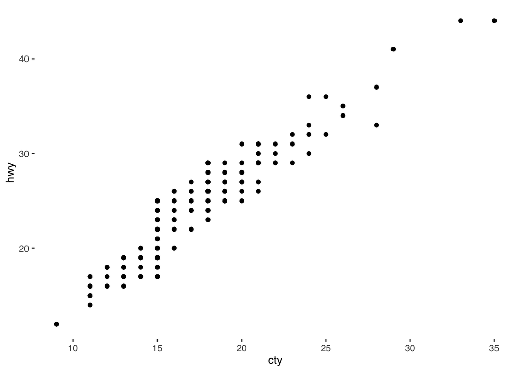

```r
#examine rel btwn cty and hwy

qplot(x=cty, y=hwy, data=mpg)
```

One more: displ vs cty.

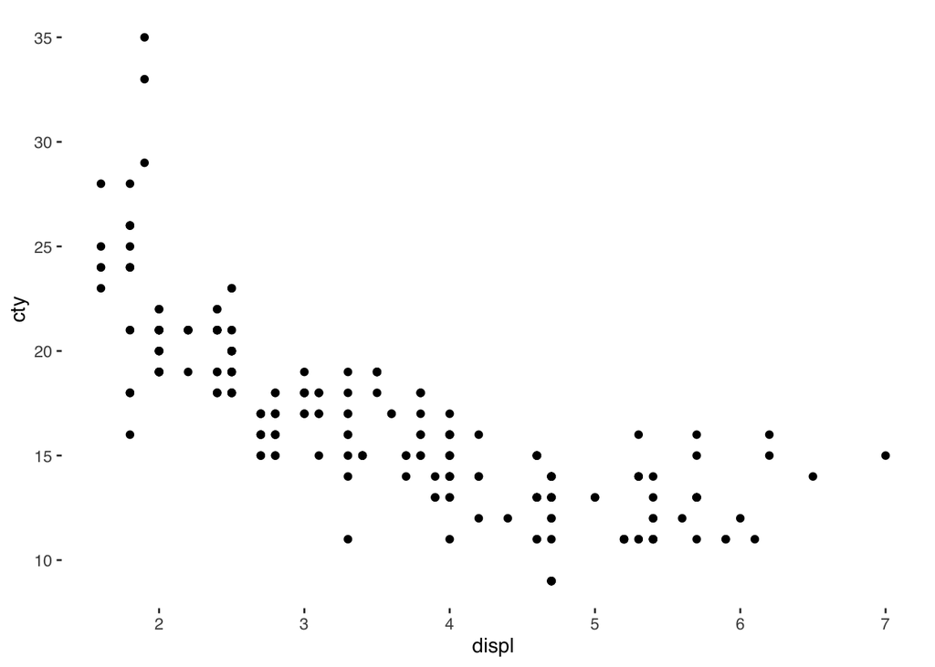

```r
qplot(displ, cty, data=mpg, geom="point")
```

### Key qualities of a linear relationship

1. Form/shape. Here in 120, we only do linear relationships. But, there are many kinds: exponential, logistic, polynomial, etc.
2. Direction: pos or neg.

In examples, the first cty vs hwy is positive. Both go up together! However, displ vs cty is a negative rel: if displ gets bigger, cty gets smaller.

3. Strength. In our examples, cty/hwy is stronger than displ/cty.

## Linear correlation coefficient r

Note: this little “r” is different from our big “R”.

The correl coefficient r measures the strength and direction of our relationship.

If r is close to 1, strong pos rel.

If r is close to -1, strong neg rel.

If r is close to zero, there’s not a linear relationship.

Warning! r only describes linear relationships. Ex on board:

##### Properties of r

- -1 < r < 1 always!!!!! (not possible to have r=1.3)
- doesn’t matter which is x, which is y
- r doesn’t depend on units (i.e. feet/meters) (whew! don’t have to worry about data units!!)

### Example: 8.8 on page 314

Identifying r in graphs.

## Least Squares Equation

### The equation

It’s a line! In high school, you wrote:

y = mx+b

In stats, we use different letters:

yhat = b_1 *x + b_0

b_1 is the slope (like m)

b_0 is the intercept (like b)

Exactly the same!

#### Example: mpg data

```r
# in R, we use lm for linear model.

# here's how to find equation for cty and hwy in mpg:



lm(hwy~cty, data=mpg)
```

```
##
## Call:
## lm(formula = hwy ~ cty, data = mpg)
##
## Coefficients:
## (Intercept)          cty
##       0.892        1.337
```

```r
mpg %>% head
```

| manufacturer | model | displ | year | cyl | trans | drv | cty | hwy | fl | class |
| --- | --- | --- | --- | --- | --- | --- | --- | --- | --- | --- |
| audi | a4 | 1.8 | 1999 | 4 | auto(l5) | f | 18 | 29 | p | compact |
| audi | a4 | 1.8 | 1999 | 4 | manual(m5) | f | 21 | 29 | p | compact |
| audi | a4 | 2.0 | 2008 | 4 | manual(m6) | f | 20 | 31 | p | compact |
| audi | a4 | 2.0 | 2008 | 4 | auto(av) | f | 21 | 30 | p | compact |
| audi | a4 | 2.8 | 1999 | 6 | auto(l5) | f | 16 | 26 | p | compact |
| audi | a4 | 2.8 | 1999 | 6 | manual(m5) | f | 18 | 26 | p | compact |

Observations:

- The ~ has a special meaning: here, hwy is a function of cty. Note that y comes first: here, that’s hwy fuel efficiency.
- I.e., we’re predicting hwy based on cty.

Let’s visualize:

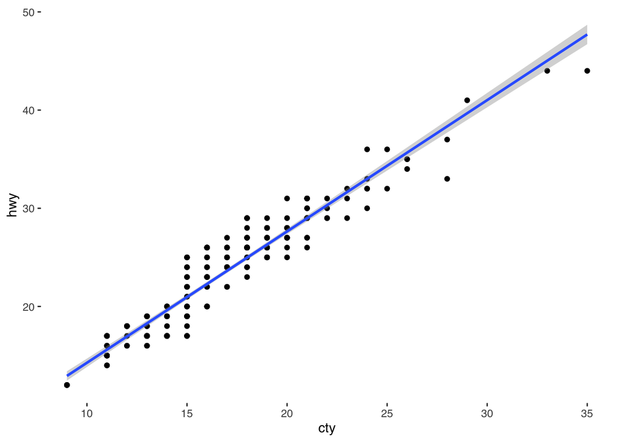

```r
qplot(cty, hwy, data=mpg)+geom_smooth(method = "lm")
```

```r
#what's R?  use cor()

cor(mpg$cty, mpg$hwy)
```

```
## [1] 0.9559159
```

Challenge: plot displ vs cty, find correlation coeff, and plot the line

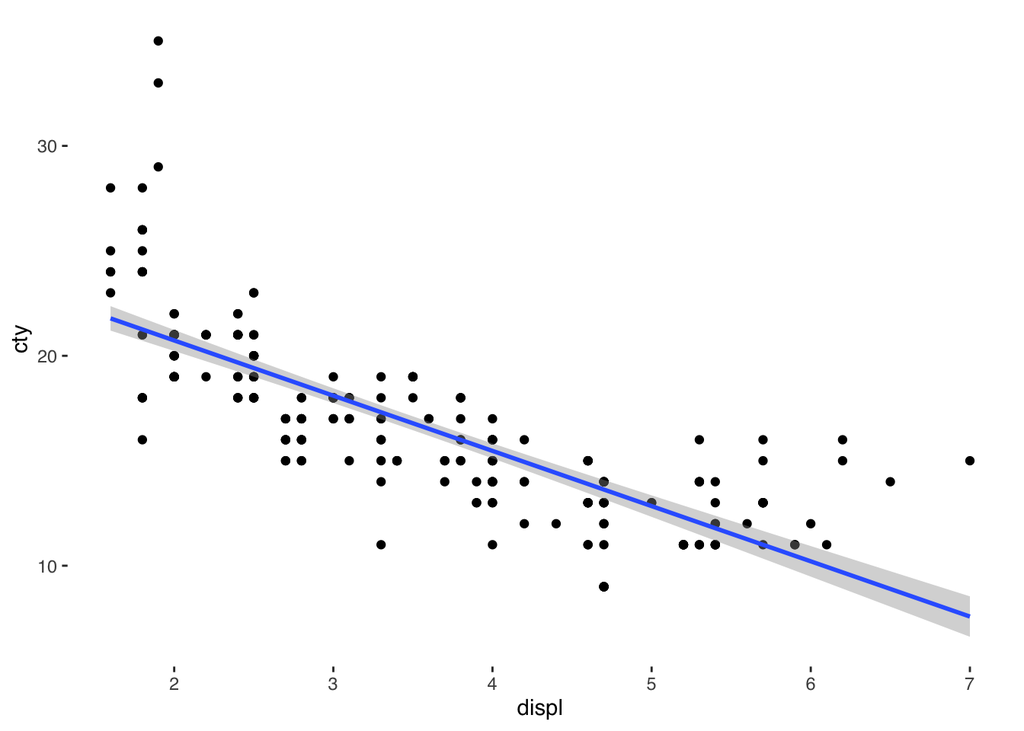

```r
qplot(displ, cty, data=mpg)+geom_smooth(method="lm")
```

```r
lm(cty ~ displ, data=mpg)
```

```
##
## Call:
## lm(formula = cty ~ displ, data = mpg)
##
## Coefficients:
## (Intercept)        displ
##       25.99        -2.63
```

```r
cor(mpg$cty, mpg$displ)
```

```
## [1] -0.798524
```

### Uniqueness

There’s only one “best” fit line. Whew!

### Using lm in R

```r
mpgModel <- lm(hwy~cty, data=mpg)

summary(mpgModel)
```

```
##
## Call:
## lm(formula = hwy ~ cty, data = mpg)
##
## Residuals:
##     Min      1Q  Median      3Q     Max
## -5.3408 -1.2790  0.0214  1.0338  4.0461
##
## Coefficients:
##             Estimate Std. Error t value Pr(>|t|)
## (Intercept)  0.89204    0.46895   1.902   0.0584 .
## cty          1.33746    0.02697  49.585   <2e-16 ***
## ---
## Signif. codes:  0 '***' 0.001 '**' 0.01 '*' 0.05 '.' 0.1 ' ' 1
##
## Residual standard error: 1.752 on 232 degrees of freedom
## Multiple R-squared:  0.9138, Adjusted R-squared:  0.9134
## F-statistic:  2459 on 1 and 232 DF,  p-value: < 2.2e-16
```

```r
predict(mpgModel, data.frame(cty=c(20,21)))
```

```
##        1        2
## 27.64115 28.97861
```

```r
.89204 + 1.33746*20
```

```
## [1] 27.64124
```

```r
class(mpgModel)
```

```
## [1] "lm"
```

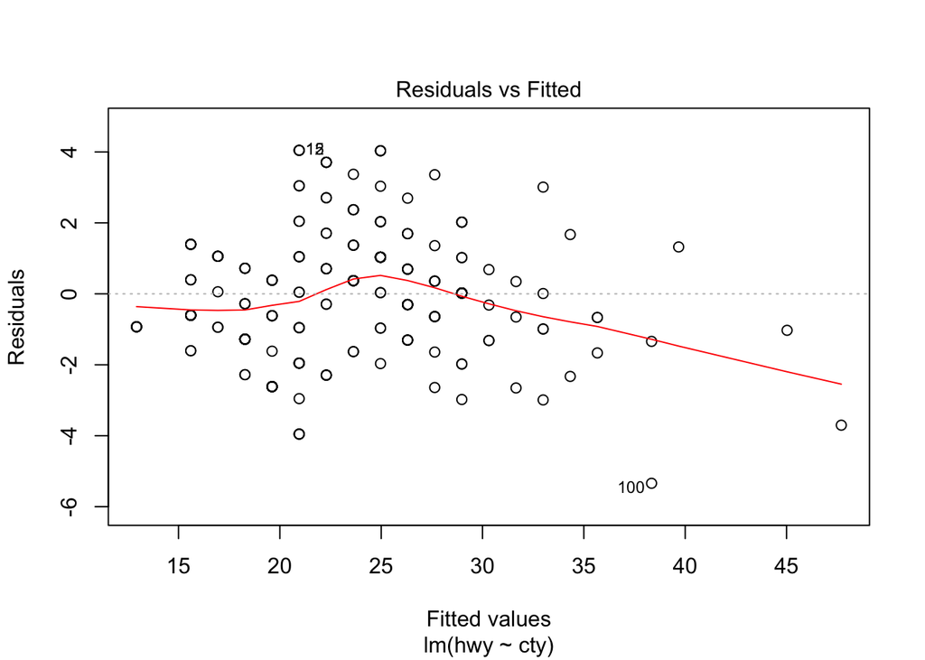

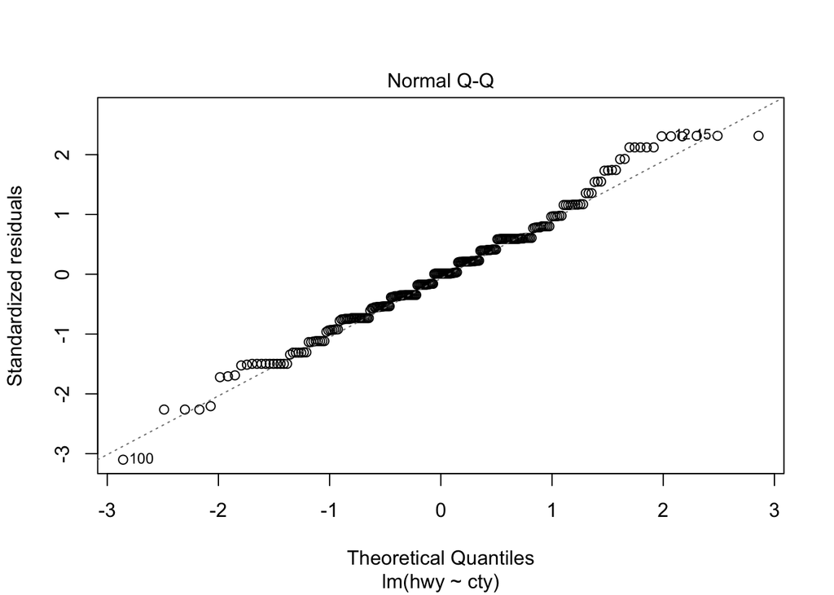

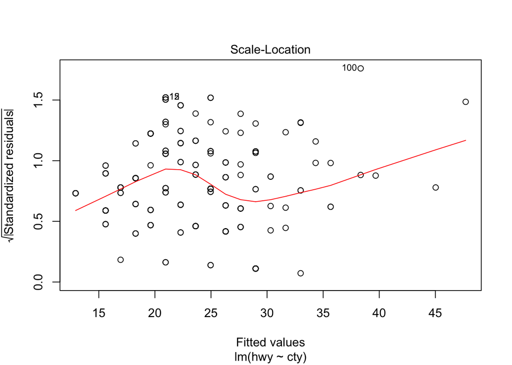

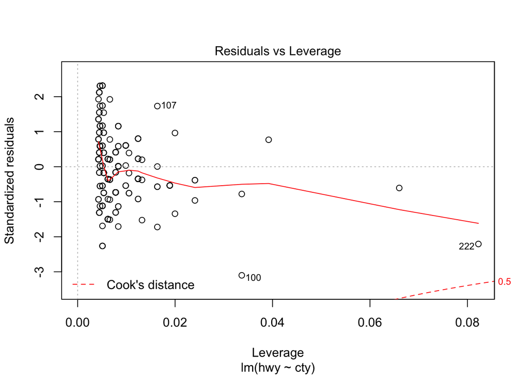

```r
plot(mpgModel)
```

### Meaning of the coefficients

## Residuals

### Meaning (math and graphical)

### Example: mpg data

### Interpreting Residual Plots

##Effects of Outliers